# Model(2):-Water pump sensor Failure Prediction

#### Context

- Water pump sensor Failure Prediction is something what comes under the hardware machine failure. There are 7 system failure in last year. Those failure cause huge problem to many people and also lead to some serious living problem of some family. The team can't see any pattern in the data when the system goes down, so they are not sure where to put more attention, we try to predict next failure using Machine Learning techniques.

#### Content

- The data are from all available sensor, all of them are raw value. Total sensor are 52 unit.

#### Inspiration

- I hope that we can predict next failure before it's happen

#### About this file

- This file contain 3 main group of data
- Timestamp data
- Sensor data(52 series): All values are raw values
- Machine status: This is target label that I want to predict when the failure will happen

### Data

- https://www.kaggle.com/nphantawee/pump-sensor-data

# importing package

```python
#import all the necessary packages.
import matplotlib.pyplot as plt
import numpy as np
import pandas as pd
import warnings
import re

import seaborn as sns
from collections import Counter
from matplotlib import gridspec
from scipy.sparse import hstack
import plotly
import plotly.figure_factory as ff
from plotly.graph_objs import Scatter, Layout
from sklearn.preprocessing import normalize
from xgboost import XGBClassifier
from sklearn.calibration import CalibratedClassifierCV
from sklearn.linear_model import LogisticRegression
from sklearn.metrics import log_loss
from sklearn.metrics import confusion_matrix

plotly.offline.init_notebook_mode(connected=True)
warnings.filterwarnings("ignore")
import pickle
from imblearn.over_sampling import SMOTE
from sklearn.model_selection import train_test_split
from sklearn.impute import SimpleImputer
```

# loading the data

```python
data = pd.read_csv('Model_2//sensor.csv')
```

```python
print('Number of data points', data.shape[0])
print('Number of features ', data.shape[1])
print('Features : ', data.columns.values)
data.head()
```

```
Number of data points 220320
Number of features  55
Features :  ['Unnamed: 0' 'timestamp' 'sensor_00' 'sensor_01' 'sensor_02' 'sensor_03'
 'sensor_04' 'sensor_05' 'sensor_06' 'sensor_07' 'sensor_08' 'sensor_09'
 'sensor_10' 'sensor_11' 'sensor_12' 'sensor_13' 'sensor_14' 'sensor_15'
 'sensor_16' 'sensor_17' 'sensor_18' 'sensor_19' 'sensor_20' 'sensor_21'
 'sensor_22' 'sensor_23' 'sensor_24' 'sensor_25' 'sensor_26' 'sensor_27'
 'sensor_28' 'sensor_29' 'sensor_30' 'sensor_31' 'sensor_32' 'sensor_33'
 'sensor_34' 'sensor_35' 'sensor_36' 'sensor_37' 'sensor_38' 'sensor_39'
 'sensor_40' 'sensor_41' 'sensor_42' 'sensor_43' 'sensor_44' 'sensor_45'
 'sensor_46' 'sensor_47' 'sensor_48' 'sensor_49' 'sensor_50' 'sensor_51'
 'machine_status']
```

|  | Unnamed: 0 | timestamp | sensor_00 | sensor_01 | sensor_02 | sensor_03 | sensor_04 | sensor_05 | sensor_06 | sensor_07 | ... | sensor_43 | sensor_44 | sensor_45 | sensor_46 | sensor_47 | sensor_48 | sensor_49 | sensor_50 | sensor_51 | machine_status |
| --- | --- | --- | --- | --- | --- | --- | --- | --- | --- | --- | --- | --- | --- | --- | --- | --- | --- | --- | --- | --- | --- |
| 0 | 0 | 2018-04-01 00:00:00 | 2.465394 | 47.09201 | 53.2118 | 46.310760 | 634.3750 | 76.45975 | 13.41146 | 16.13136 | ... | 41.92708 | 39.641200 | 65.68287 | 50.92593 | 38.194440 | 157.9861 | 67.70834 | 243.0556 | 201.3889 | NORMAL |
| 1 | 1 | 2018-04-01 00:01:00 | 2.465394 | 47.09201 | 53.2118 | 46.310760 | 634.3750 | 76.45975 | 13.41146 | 16.13136 | ... | 41.92708 | 39.641200 | 65.68287 | 50.92593 | 38.194440 | 157.9861 | 67.70834 | 243.0556 | 201.3889 | NORMAL |
| 2 | 2 | 2018-04-01 00:02:00 | 2.444734 | 47.35243 | 53.2118 | 46.397570 | 638.8889 | 73.54598 | 13.32465 | 16.03733 | ... | 41.66666 | 39.351852 | 65.39352 | 51.21528 | 38.194443 | 155.9606 | 67.12963 | 241.3194 | 203.7037 | NORMAL |
| 3 | 3 | 2018-04-01 00:03:00 | 2.460474 | 47.09201 | 53.1684 | 46.397568 | 628.1250 | 76.98898 | 13.31742 | 16.24711 | ... | 40.88541 | 39.062500 | 64.81481 | 51.21528 | 38.194440 | 155.9606 | 66.84028 | 240.4514 | 203.1250 | NORMAL |
| 4 | 4 | 2018-04-01 00:04:00 | 2.445718 | 47.13541 | 53.2118 | 46.397568 | 636.4583 | 76.58897 | 13.35359 | 16.21094 | ... | 41.40625 | 38.773150 | 65.10416 | 51.79398 | 38.773150 | 158.2755 | 66.55093 | 242.1875 | 201.3889 | NORMAL |

5 rows × 55 columns

```python
unique_label = set(data['machine_status'])
print("Unique values in class_label",unique_label)
```

```
Unique values in class_label {'NORMAL', 'RECOVERING', 'BROKEN'}
```

### data distribution

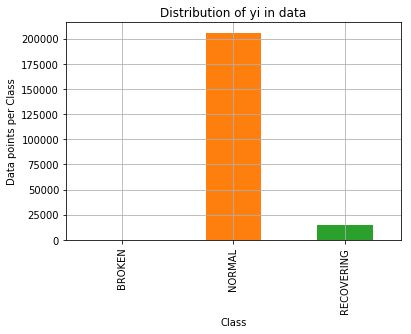

```
Number of data points in class 2 205836
Number of data points in class 3 14477
Number of data points in class 1 7
```

```python
plot_data = data['machine_status'].value_counts().sortlevel()

plot_data.plot(kind='bar')
plt.xlabel('Class')
plt.ylabel('Data points per Class')
plt.title('Distribution of yi in data')
plt.grid()
plt.show()

sorted_yi = np.argsort(-plot_data.values)
for i in sorted_yi:
    print('Number of data points in class', i+1, plot_data.values[i])
```

### changing notation,

**Normal** as 0 means **"No action required"**  
**Recovering** as 1 means **"Action required"**

```python
class_label = []
for i in data['machine_status']:
    if i == 'NORMAL':
        class_label.append(0)
    elif i == 'RECOVERING':
        class_label.append(1)
    else:
        class_label.append(2)

data.drop(['machine_status'],axis=1,inplace=True)
data['machine_status'] = class_label
data.head(2)
```

|  | Unnamed: 0 | timestamp | sensor_00 | sensor_01 | sensor_02 | sensor_03 | sensor_04 | sensor_05 | sensor_06 | sensor_07 | ... | sensor_43 | sensor_44 | sensor_45 | sensor_46 | sensor_47 | sensor_48 | sensor_49 | sensor_50 | sensor_51 | machine_status |
| --- | --- | --- | --- | --- | --- | --- | --- | --- | --- | --- | --- | --- | --- | --- | --- | --- | --- | --- | --- | --- | --- |
| 0 | 0 | 2018-04-01 00:00:00 | 2.465394 | 47.09201 | 53.2118 | 46.31076 | 634.375 | 76.45975 | 13.41146 | 16.13136 | ... | 41.92708 | 39.6412 | 65.68287 | 50.92593 | 38.19444 | 157.9861 | 67.70834 | 243.0556 | 201.3889 | 0 |
| 1 | 1 | 2018-04-01 00:01:00 | 2.465394 | 47.09201 | 53.2118 | 46.31076 | 634.375 | 76.45975 | 13.41146 | 16.13136 | ... | 41.92708 | 39.6412 | 65.68287 | 50.92593 | 38.19444 | 157.9861 | 67.70834 | 243.0556 | 201.3889 | 0 |

2 rows × 55 columns

```python
data.drop(['Unnamed: 0','timestamp'],axis=1,inplace=True)
```

```python
#removing data with machine_status = 2
data = data.drop(data[data['machine_status'] == 2].index)
```

```python
unique_label = set(data['machine_status'])
print("Unique values in class_label",unique_label)
```

```
Unique values in class_label {0, 1}
```

### dealing with missing values

```python
# checking the Null for train data:-
data.isnull().sum()
```

```
sensor_00          10208
sensor_01            369
sensor_02             19
sensor_03             19
sensor_04             19
sensor_05             19
sensor_06           4798
sensor_07           5451
sensor_08           5107
sensor_09           4595
sensor_10             19
sensor_11             19
sensor_12             19
sensor_13             19
sensor_14             21
sensor_15         220313
sensor_16             31
sensor_17             46
sensor_18             46
sensor_19             16
sensor_20             16
sensor_21             16
sensor_22             41
sensor_23             16
sensor_24             16
sensor_25             36
sensor_26             20
sensor_27             16
sensor_28             16
sensor_29             72
sensor_30            261
sensor_31             16
sensor_32             68
sensor_33             16
sensor_34             16
sensor_35             16
sensor_36             16
sensor_37             16
sensor_38             27
sensor_39             27
sensor_40             27
sensor_41             27
sensor_42             27
sensor_43             27
sensor_44             27
sensor_45             27
sensor_46             27
sensor_47             27
sensor_48             27
sensor_49             27
sensor_50          77016
sensor_51          15382
machine_status         0
dtype: int64
```

```python
## as all data is empty
data.drop(['sensor_15'],axis=1,inplace=True)
```

# Random splitting of data

```python
train_data, test_data, train_y, test_y = train_test_split(data, data['machine_status'], test_size=0.20, stratify=data['machine_status'])
```

## using mean imputation

```python
imp_mean = SimpleImputer(missing_values=np.nan, strategy='mean').fit(data)
train_data = pd.DataFrame(imp_mean.transform(train_data), columns=train_data.columns)
test_data = pd.DataFrame(imp_mean.transform(test_data), columns=test_data.columns)
```

```python
train_data.isnull().values.any()
```

```
False
```

```python
test_data.isnull().values.any()
```

```
False
```

#### sampling data for checking model at last

```python
sample_normal = test_data[test_data['machine_status'] == 0].sample(n=10)
sample_recovering = test_data[test_data['machine_status'] == 1].sample(n=10)

normal_yi = sample_normal['machine_status']
recovering_yi = sample_recovering['machine_status']

sample_normal.drop(['machine_status'],axis=1,inplace=True)
sample_recovering.drop(['machine_status'],axis=1,inplace=True)
```

```python
sample_normal = pd.DataFrame(normalize(sample_normal))
sample_recovering = pd.DataFrame(normalize(sample_recovering))
```

```python
exoprt_nor = sample_normal.to_csv('Sample_data/Model_2/sample_negative.csv')
exoprt_recov = sample_recovering.to_csv('Sample_data/Model_2/sample_positive.csv')
```

### Distribution of Class_label

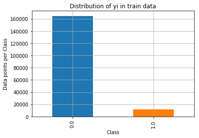

```
Number of data points in class 1 : 164668 ( 93.429 %)
Number of data points in class 2 : 11582 ( 6.571 %)
--------------------------------------------------------------------------------
```

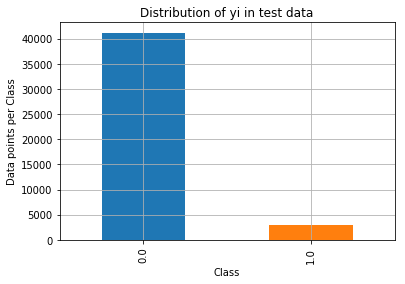

```
Number of data points in class 1 : 41168 ( 93.43 %)
Number of data points in class 2 : 2895 ( 6.57 %)
```

```python
# it returns a dict, keys as class labels and values as the number of data points in that class
train_class_distribution = train_data['machine_status'].value_counts().sortlevel()
test_class_distribution = test_data['machine_status'].value_counts().sortlevel()

train_class_distribution.plot(kind='bar')
plt.xlabel('Class')
plt.ylabel('Data points per Class')
plt.title('Distribution of yi in train data')
plt.grid()
plt.show()

sorted_yi = np.argsort(-train_class_distribution.values)
for i in sorted_yi:
    print('Number of data points in class', i+1, ':',train_class_distribution.values[i], '(', np.round((train_class_distribution.values[i]/train_data.shape[0]*100), 3), '%)')


print('-'*80)
my_colors = 'rgbkymc'
test_class_distribution.plot(kind='bar')
plt.xlabel('Class')
plt.ylabel('Data points per Class')
plt.title('Distribution of yi in test data')
plt.grid()
plt.show()

sorted_yi = np.argsort(-test_class_distribution.values)
for i in sorted_yi:
    print('Number of data points in class', i+1, ':',test_class_distribution.values[i], '(', np.round((test_class_distribution.values[i]/test_data.shape[0]*100), 3), '%)')
```

##### Distribution of class label is same for train and test

```python
exoprt_train = train_data.to_csv('Model_2/pump_train_data.csv')
exoprt_test = test_data.to_csv('Model_2/pump_test_data.csv')
```

### Normalizing the whole data.

- helps in getting rid of scale

```python
# train
train_data.drop(['machine_status'],axis=1,inplace=True)
train_data = normalize(train_data)
```

```python
# test
test_data.drop(['machine_status'],axis=1,inplace=True)
test_data = normalize(test_data)
```

```python
# This function plots the confusion matrices given y_i, y_i_hat.
def plot_confusion_matrix(test_y, predict_y):
    C = confusion_matrix(test_y, predict_y)

    A =(((C.T)/(C.sum(axis=1))).T)

    B =(C/C.sum(axis=0))

    labels = [0,1]

    # representing A in heatmap format
    print("-"*20, "Confusion matrix", "-"*20)
    plt.figure(figsize=(4,3))
    sns.heatmap(C, annot=True, cmap="YlGnBu", fmt=".3f", xticklabels=labels, yticklabels=labels)
    plt.xlabel('Predicted Class')
    plt.ylabel('Original Class')
    plt.show()

    print("-"*20, "Precision matrix (Columm Sum=1)", "-"*20)
    plt.figure(figsize=(4,3))
    sns.heatmap(B, annot=True, cmap="YlGnBu", fmt=".3f", xticklabels=labels, yticklabels=labels)
    plt.xlabel('Predicted Class')
    plt.ylabel('Original Class')
    plt.show()

    # representing B in heatmap format
    print("-"*20, "Recall matrix (Row sum=1)", "-"*20)
    plt.figure(figsize=(4,3))
    sns.heatmap(A, annot=True, cmap="YlGnBu", fmt=".3f", xticklabels=labels, yticklabels=labels)
    plt.xlabel('Predicted Class')
    plt.ylabel('Original Class')
    plt.show()
```

# performing over_sampling to get rid of class imbalance

```python
def SMOTE_oversmapling(X, Y):
    sm = SMOTE(ratio = 1.0)
    X_ovs,Y_ovs = sm.fit_sample(X, Y)
    print(X_ovs.shape, Y_ovs.shape)
    print(np.bincount(Y_ovs))
    return X_ovs, Y_ovs
```

```python
train_data , train_y = SMOTE_oversmapling(train_data, train_y)
```

```
(329336, 51) (329336,)
[164668 164668]
```

```python
print("train data shape",train_data.shape,train_y.shape)
print("test data shape",test_data.shape,test_y.shape)
```

```
train data shape (329336, 51) (329336,)
test data shape (44063, 51) (44063,)
```

## Performing xgboost for binary classification

```python
from sklearn.model_selection import RandomizedSearchCV
x_cfl=XGBClassifier()
prams={'n_estimators':[10,50,100,200],
     'max_depth':[5,10,20,50]}
random_clf = RandomizedSearchCV(x_cfl,prams,scoring='neg_log_loss',cv=5,n_jobs=-1)
random_clf.fit(train_data,train_y)
```

```
RandomizedSearchCV(cv=5, error_score='raise-deprecating',
                   estimator=XGBClassifier(base_score=0.5, booster='gbtree',
                                           colsample_bylevel=1,
                                           colsample_bynode=1,
                                           colsample_bytree=1, gamma=0,
                                           learning_rate=0.1, max_delta_step=0,
                                           max_depth=3, min_child_weight=1,
                                           missing=None, n_estimators=100,
                                           n_jobs=1, nthread=None,
                                           objective='binary:logistic',
                                           random_state=0, reg_alpha=0,
                                           reg_lambda=1, scale_pos_weight=1,
                                           seed=None, silent=None, subsample=1,
                                           verbosity=1),
                   iid='warn', n_iter=10, n_jobs=-1,
                   param_distributions={'max_depth': [5, 10, 20, 50],
                                        'n_estimators': [10, 50, 100, 200]},
                   pre_dispatch='2*n_jobs', random_state=None, refit=True,
                   return_train_score=False, scoring='neg_log_loss', verbose=0)
```

```python
random_clf.best_params_
```

```
{'n_estimators': 200, 'max_depth': 5}
```

*Best parameters are:-*

- **max_depth = 5**
- **n_estimators = 200**

```
train loss 0.0001071925110000206
test loss 0.0011439419668003278
-------------------- Confusion matrix --------------------
```

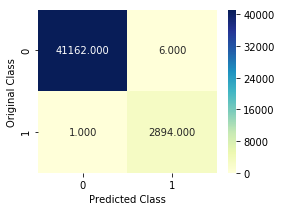

```
-------------------- Precision matrix (Columm Sum=1) --------------------
```

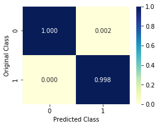

```
-------------------- Recall matrix (Row sum=1) --------------------
```

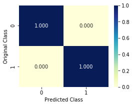

```python
x_clf = XGBClassifier(n_estimators=200,max_depth=5,n_jobs= -1)
x_clf.fit(train_data,train_y)
c_cfl=CalibratedClassifierCV(x_clf,method='sigmoid')
c_cfl.fit(train_data,train_y)

predict_y = c_cfl.predict_proba(train_data)
print ('train loss',log_loss(train_y, predict_y))

predict_y = c_cfl.predict_proba(test_data)
print ('test loss',log_loss(test_y, predict_y))
plot_confusion_matrix(test_y,c_cfl.predict(test_data))
```

```python
# save the model to disk
filename = 'final_model_2.sav'
pickle.dump(c_cfl, open(filename, 'wb'))


# load the model from disk
loaded_model = pickle.load(open(filename, 'rb'))
```

```python
sample_normal += 0.000001
sample_recovering += 0.000001
```

```python
predict_y_pos = loaded_model.predict(sample_normal)
predict_y_pos
```

```
array([0, 0, 0, 0, 0, 0, 0, 0, 0, 0], dtype=int64)
```

```python
predict_y_neg = loaded_model.predict(sample_recovering)
predict_y_neg
```

```
array([1, 1, 1, 1, 1, 1, 1, 1, 1, 1], dtype=int64)
```

# Its WoW :)